# Alluvium Plot

# Alluvium Plot with ggplot2

- Use [ggplot2](https://cran.r-project.org/web/packages/ggplot2/index.html) and [ggalluvial](https://cran.r-project.org/web/packages/ggalluvial/index.html) package, plus [ggrepel](https://cran.r-project.org/web/packages/ggrepel/index.html) package

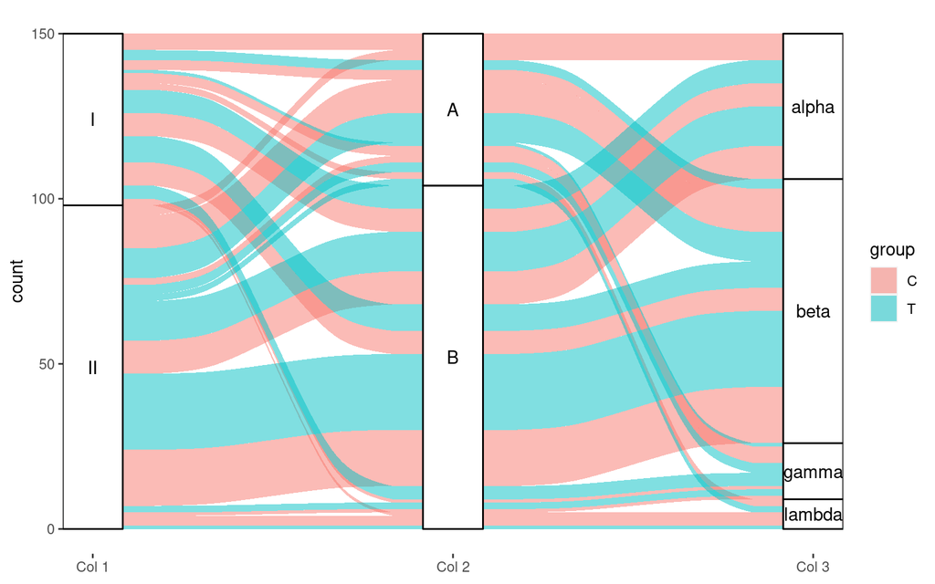

```r
library(data.table)
library(ggplot2)
library(ggalluvial)
library(ggrepel)
dt <- data.table(
    id = 1:150
  , col1 = factor(sample(c("I", "II"), size = 150, replace = TRUE, prob = c(0.4, 0.6)))
  , col2 = factor(sample(c("A", "B"), size = 150, replace = TRUE, prob = c(0.3, 0.7)))
  , col3 = factor(sample(c("alpha", "beta", "gamma", "lambda"), size = 150, replace = TRUE, prob = c(0.3, 0.5, 0.1, 0.1)))
  , group = rep(c("T", "C"), 75)
)

fq <- dt[, .(count = .N), by = .(col1, col2, col3, group)]

ggplot(as.data.frame(fq),
      aes(y = count
        , axis1 = col1
        , axis2 = col2
        , axis3 = col3
        )) +
   geom_alluvium(aes(fill = group), width=1/3) +
   geom_stratum(width = 1/6) +
   geom_text(stat = "stratum", aes(label = after_stat(stratum))) +
   ## geom_label_repel(stat = "stratum", infer.label = TRUE, label.strata=TRUE) +
   scale_x_discrete(limits = c("Col 1", "Col 2"
                             , "Col 3"
                               )
                  , expand = c(.0, .0)) +
   ## theme_bw() +
   theme(panel.grid.major = element_blank()
       , panel.grid.minor = element_blank()
       , panel.background = element_blank()
       , panel.border = element_blank())
```

# geom_flow

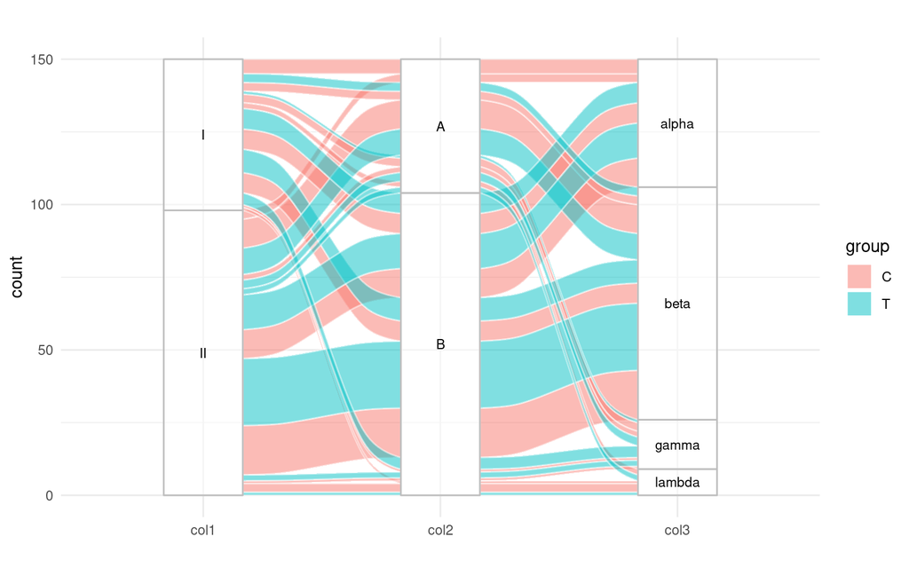

```r
ggplot(data = fq
     , aes(
           y = count
         , axis1 = col1
         , axis2 = col2
         , axis3 = col3
       )) +
    geom_flow(
        aes(fill = group), stat = "alluvium"
      , lode.guidance = "rightleft"
      , color = "white"
      , na.rm = TRUE
    ) +
    scale_x_discrete(limits = c("col1", "col2", "col3")) +
    geom_stratum(alpha = .5, na.rm = TRUE, color = "grey") +
    geom_text(stat = "stratum", size = 3, aes(label = after_stat(stratum))) +
    ggtitle("") +
    xlab("") +
    theme_minimal()
```

```r
## theme(legend.position = "none")
```

R version 4.2.0 (2022-04-22) Platform: x86_64-pc-linux-gnu (64-bit) Running under: Ubuntu 20.04.3 LTS

Matrix products: default BLAS: /usr/lib/x86_64-linux-gnu/blas/libblas.so.3.9.0 LAPACK: /usr/lib/x86_64-linux-gnu/lapack/liblapack.so.3.9.0

locale: [1] LC_CTYPE=C.UTF-8 LC_NUMERIC=C LC_TIME=C.UTF-8  
[4] LC_COLLATE=C.UTF-8 LC_MONETARY=C.UTF-8 LC_MESSAGES=C.UTF-8  
[7] LC_PAPER=C.UTF-8 LC_NAME=C LC_ADDRESS=C  
[10] LC_TELEPHONE=C LC_MEASUREMENT=C.UTF-8 LC_IDENTIFICATION=C

attached base packages: [1] stats graphics grDevices utils datasets methods base